# final_project

Name: Branden Do Hyun Kang Net ID: dhk416

# Introduction

This analysis report focuses on two outcome variables: maternal mortality ratio and fertility rate, and explores whether these outcome variables have a causal relationship with predictors such as the precentage of women receiving prenatal care, the prevalence of contraceptive methods, and the prevalence of anemia among women of reproductive age. The predictor that I have chosen to focus on for this report is the prevalence of anemia among women of reproductive age. The reason behind this is that anemia is a condition that often develops during pregnancy, when a woman’s blood lacks enough healthy red blood cells or hemoglobin due to the excess amount of blood her body produces to help provide nutrients for the baby. Anemia has been reported as one of the leading causes of maternal deaths, and because it most directly affects the health of pregnant women (among the other predictor variables) and has been known to cause maternal deaths, it would be interesting to explore whether anemia also has an effect on fertility rates. I assume that there will be a positive relationship between the percentage of women receiving prenatal care and the fertility rate, a negative relationship between the percentage of women receiving prenatal care and the maternal mortality ratio, a negative relationship between contraceptive prevalence and maternal mortality ratio (perhaps due to a decrease in HIV/AIDS) and a negative relationship between contraceptive prevalence and fertility rate, and a positive relationship between the prevalence of anemia among women of reproductive age and maternal mortality ratio, and a negative relationship between the prevalence of anemia among women of reproductive age and fertility rate. In order to conduct the analysis I have used several statistical methods, to fit regression models based on the outcome variables, using an F-test to compare them, analyzing the confidence intervals for the central predictor variable, comparing p-values and R-squared values, and plotting and interpreting the regression diagnostic plots for differences between the models.

```r
library(tidyverse)
library(wbstats)
```

# Choosing the outcome and predictor variables

# Units of measurement for variables

```r
#outcome variables
wbsearch(pattern = "maternal mortality ratio")
```

```
##             indicatorID
## 4675     SH.STA.MMRT.NE
## 4676        SH.STA.MMRT
## 10727 5.51.01.06.matern
##                                                                   indicator
## 4675  Maternal mortality ratio (national estimate, per 100,000 live births)
## 4676   Maternal mortality ratio (modeled estimate, per 100,000 live births)
## 10727                                                       Maternal health
```

```r
wbsearch(pattern = "fertility rate")
```

```
##         indicatorID
## 3463    SP.ADO.TFRT
## 4057 SP.FER.TOTL.ZR
## 4058 SP.DYN.WFRT.Q5
## 4059 SP.DYN.WFRT.Q4
## 4060 SP.DYN.WFRT.Q3
## 4061 SP.DYN.WFRT.Q2
## 4062 SP.DYN.WFRT.Q1
## 4063    SP.DYN.WFRT
## 4066 SP.DYN.TFRT.Q5
## 4067 SP.DYN.TFRT.Q4
## 4068 SP.DYN.TFRT.Q3
## 4069 SP.DYN.TFRT.Q2
## 4070 SP.DYN.TFRT.Q1
## 4071 SP.DYN.TFRT.IN
```

[output cut: 17 more lines]

```r
#1. Maternal mortality ratio (modeled estimate, per 100,000 live births)
#2. Fertility rate, total (births per woman)

#predictor variables
wbsearch(pattern = "prenatal care")
```

```
##           indicatorID
## 4777   SH.STA.ANVC.ZS
## 4777.1 SH.STA.ANVC.ZS
## 4783   SH.STA.ANV4.ZS
## 4783.1 SH.STA.ANV4.ZS
##                                                                                   indicator
## 4777                                             Pregnant women receiving prenatal care (%)
## 4777.1                                           Pregnant women receiving prenatal care (%)
## 4783   Pregnant women receiving prenatal care of at least four visits (% of pregnant women)
## 4783.1 Pregnant women receiving prenatal care of at least four visits (% of pregnant women)
```

```r
wbsearch(pattern = "contraceptive prevalence")
```

```
##             indicatorID
## 3434     SP.DYN.CONU.ZS
## 3440 SP.DYN.CONU.MDN.ZS
## 3441 SP.DYN.CONU.CDM.ZS
## 3442     SP.DYN.CONM.ZS
##                                                                     indicator
## 3434            Contraceptive prevalence, any methods (% of women ages 15-49)
## 3440 Contraceptive use among married women 15-49 years old, modern method (%)
## 3441        Contraceptive use among married women 15-49 years old, condom (%)
## 3442         Contraceptive prevalence, modern methods (% of women ages 15-49)
```

```r
wbsearch(pattern = "pregnant women")
```

```
##                    indicatorID
## 785          SP.UWT.TFRT.Q5.ZS
## 786          SP.UWT.TFRT.Q4.ZS
## 787          SP.UWT.TFRT.Q3.ZS
## 2476            SH.ANM.NPRG.ZS
## 2477            SH.ANM.CHLD.ZS
## 2478            SH.ANM.ALLW.ZS
## 3497     SH.HIV.PREG.VIRALS.ZS
## 3498    SH.HIV.PREG.VIRALS.NUM
## 3499  SH.HIV.PREG.VIRALS.LW.ZS
## 3500  SH.HIV.PREG.VIRALS.HG.ZS
## 3501            SH.HIV.PMTC.ZS
## 4073         SH.MLR.PREG.Q4.ZS
## 4074         SH.MLR.PREG.Q3.ZS
## 4075         SH.MLR.PREG.Q2.ZS
```

[output cut: 95 more lines]

```r
#1.Pregnant women receiving prenatal care (%)
#2.Contraceptive prevalence, any methods (% of women ages 15-49)
#3.Prevalence of anemia among women of reproductive age (% of women ages 15-49)
```

```r
wb_variables <- c("SH.STA.MMRT",
                  "SP.DYN.TFRT.IN",
                  "SH.STA.ANVC.ZS",
                  "SP.DYN.CONU.ZS",
                  "SH.ANM.ALLW.ZS")

wb_names <- c("maternalmort",
              "fertilityrate",
              "prenatalcare",
              "contraceptives",
              "anemia")

wb_data <- wb(country = "all", indicator = wb_variables,
          startdate = 2007, enddate = 2018, return_wide = TRUE)

wb_recent <- wb_data %>%
  rename_at(vars(wb_variables), ~ wb_names) %>% # rename
  drop_na() %>%                                 # remove missing
  group_by(country) %>%
  arrange(date) %>%
  top_n(1) %>%
  ungroup()
# Countries included
wb_recent$country
```

```
##   [1] "Bangladesh"
##   [2] "Brazil"
##   [3] "Bhutan"
##   [4] "Botswana"
##   [5] "Congo, Dem. Rep."
##   [6] "Dominican Republic"
##   [7] "Indonesia"
##   [8] "Jordan"
##   [9] "Liberia"
##  [10] "Libya"
##  [11] "Sri Lanka"
##  [12] "Myanmar"
##  [13] "Mauritania"
##  [14] "Namibia"
##  [15] "Nicaragua"
```

[output cut: 138 more lines]

```r
# Number of countries included
nrow(wb_recent)
```

```
## [1] 153
```

# Regression model 1 with maternal mortality ratio as the outcome, using all predictors

```r
#fit model
model1 <- lm(maternalmort ~ prenatalcare + contraceptives + anemia, wb_recent)

#show summaries
summary(model1)
```

```
##
## Call:
## lm(formula = maternalmort ~ prenatalcare + contraceptives + anemia,
##     data = wb_recent)
##
## Residuals:
##     Min      1Q  Median      3Q     Max
## -372.64 -117.65  -12.11   79.30 1130.31
##
## Coefficients:
##                Estimate Std. Error t value Pr(>|t|)
## (Intercept)    676.4254   151.2065   4.474 1.52e-05 ***
## prenatalcare    -3.4063     1.3091  -2.602  0.01020 *
## contraceptives  -6.2816     0.9252  -6.789 2.50e-10 ***
## anemia           5.4814     1.8138   3.022  0.00296 **
## ---
## Signif. codes:  0 '***' 0.001 '**' 0.01 '*' 0.05 '.' 0.1 ' ' 1
##
## Residual standard error: 185.9 on 149 degrees of freedom
## Multiple R-squared:  0.5461, Adjusted R-squared:  0.537
## F-statistic: 59.77 on 3 and 149 DF,  p-value: < 2.2e-16
```

```r
#P-value for chosen predictor (anemia): 0.003
#Adjusted R-squared: 0.537
```

# Regression model 2 with maternal mortality ratio as the outcome, using prevalence of prenatal care and anemia as predictors

```r
#fit model
model2 <- lm(maternalmort ~ prenatalcare + anemia, wb_recent)

#show summaries
summary(model2)
```

```
##
## Call:
## lm(formula = maternalmort ~ prenatalcare + anemia, data = wb_recent)
##
## Residuals:
##     Min      1Q  Median      3Q     Max
## -417.95 -132.61  -42.10   82.83 1257.75
##
## Coefficients:
##              Estimate Std. Error t value Pr(>|t|)
## (Intercept)   335.521    162.659   2.063 0.040863 *
## prenatalcare   -5.302      1.459  -3.635 0.000381 ***
## anemia         12.094      1.745   6.931 1.16e-10 ***
## ---
## Signif. codes:  0 '***' 0.001 '**' 0.01 '*' 0.05 '.' 0.1 ' ' 1
##
## Residual standard error: 212 on 150 degrees of freedom
## Multiple R-squared:  0.4057, Adjusted R-squared:  0.3978
## F-statistic: 51.21 on 2 and 150 DF,  p-value: < 2.2e-16
```

```r
#P-value for chosen predictor (anemia): 1.16e -10
#Adjusted R-squared: 0.398
```

# Interpretation of summaries: Model 1

## Estimates

The values for the coefficients of model 1 indicate that for every 1% increase in the prevalence of anemia among women of reproductive age, the maternal mortality ratio (modeled per 100,000 live births) increases by 5.481. On the other hand, for every 1% increase in pregnant women receiving prenatal care (%), the maternal mortality ratio decreases by 3.406, and for every 1% increase in contraceptive prevalence (% of women ages 15-49), the maternal mortality ratio decreases by 6.282.

## Standard Errors

The Standard Error can be used to compute an estimate of the expected difference in case we ran the model multiple times. We’ve already interpreted that for every 1% increase in the prevalence of anemia among women of reproductive age, the maternal mortality ratio (modeled per 100,000 live births) increases by 5.481. We can say that for every 1% increase in the prevalence of anemia, the change in maternal mortality ratio can vary by 1.814. And for every 1% increase in pregnant women receiving prenatal care and in the prevalence of contraception, the change in maternal mortality ratio can vary by 1.309 and 0.925 accordingly.

## t-value

The t-value is a measure of how many standard deviations our coefficient estimate is far away from 0. We want it to be far away from zero as this would indicate we could reject the null hypothesis - that is, we could deduce that a relationship between the predictors and the outcome exists. In our model, the t-statistic values are relatively slightly far from zero and are larger than the standard error, which could indicate a relationship exists.

## p-value

A small p-value indicates that it is unlikely we will observe a relationship between the predictors (anemia / prenatal care / contraceptives) and outcome (maternal mortality) due to chance. We will use a p-value of 0.05 or less as the cut-off point. In our model, the p-values for the intercept and the slope are very close to zero (<0.05). which indicates that we can reject the null hypothesis which allows us to conclude that there is a relationship between the predictors (anemia / prenatal care / contraceptives) and outcome (maternal mortality ratio).

# Interpretation of summaries: Model 2

The values for the coefficients of model 2 indicate that for every 1% increase in the prevalence of anemia among women of reproductive age, the maternal mortality ratio (modeled per 100,000 live births) increases by 12.094. On the other hand, for every 1% increase in pregnant women receiving prenatal care(%), the maternal mortality ratio decreases by 5.302.

## Standard Errors

We can say that for every 1% increase in the prevalence of anemia, the change in maternal mortality ratio can vary by 1.745. And for every 1% increase in pregnant women receiving prenatal care, the change in maternal mortality ratio can vary by 1.459.

## t-value

The t-value is a measure of how many standard deviations our coefficient estimate is far away from 0. We want it to be far away from zero as this would indicate we could reject the null hypothesis - that is, we could deduce that a relationship between the predictors and the outcome exists. In our model, the t-statistic values are relatively slightly far from zero and are larger than the standard error, which could indicate a relationship exists.

## p-value

In our model, the p-values for the intercept and the slope are very close to zero (<0.05). which indicates that we can reject the null hypothesis which allows us to conclude that there is a relationship between the predictor (anemia) and outcome (maternal mortality ratio).

## Adjusted R-squared

The adjusted R-squared value for model 1 is 0.537, while the value for model 2 is 0.398. Model 1 has the higher R-squared value, indicating that model 1 fits the data better than model 2.

# F-test

```r
anova(model1,model2)
```

```
## Analysis of Variance Table
##
## Model 1: maternalmort ~ prenatalcare + contraceptives + anemia
## Model 2: maternalmort ~ prenatalcare + anemia
##   Res.Df     RSS Df Sum of Sq      F  Pr(>F)
## 1    149 5151098
## 2    150 6744696 -1  -1593598 46.096 2.5e-10 ***
## ---
## Signif. codes:  0 '***' 0.001 '**' 0.01 '*' 0.05 '.' 0.1 ' ' 1
```

```r
#The test chooses model 1 (the full model) over the reduced model (model 2) because the p-value is smaller than 0.05.
#The data supports that the coefficients not shared between the models are not zero.
```

```r
confint(model1,level=0.95)
```

```
##                     2.5 %      97.5 %
## (Intercept)    377.639302 975.2114463
## prenatalcare    -5.993036  -0.8195095
## contraceptives  -8.109839  -4.4533970
## anemia           1.897334   9.0654765
```

```r
confint(model2,level=0.95)
```

```
##                  2.5 %     97.5 %
## (Intercept)  14.121711 656.919534
## prenatalcare -8.183911  -2.419794
## anemia        8.646405  15.542274
```

# Interpreting confidence intervals

The output indicates that a 95% confidence interval for our intercept estimate is [377.639302, 975.2114463] for model 1 and [14.121711 656.919534] for model 2. This means that we can be 95% certain that our intercept value will fall between these values for model 1 and model 2, and that if multiple confidence intervals were constructed for our intercept estimate, 95% of the intervals would include the true intercept value.

The confidence interval for our main predictor estimate (anemia) is [1.897334, 9.0654765] for model 1 and [8.646405, 15.542274] for model 2, which means that we can be 95% certain that the value of our anemia slop will fall between these values, and that if multiple confidence intervals were constructed for our slope estimate, 95% of the intervals would include the true value.

# statistical and practical significance of the main predictor (prevalence of anemia)

# Diagnostic plots

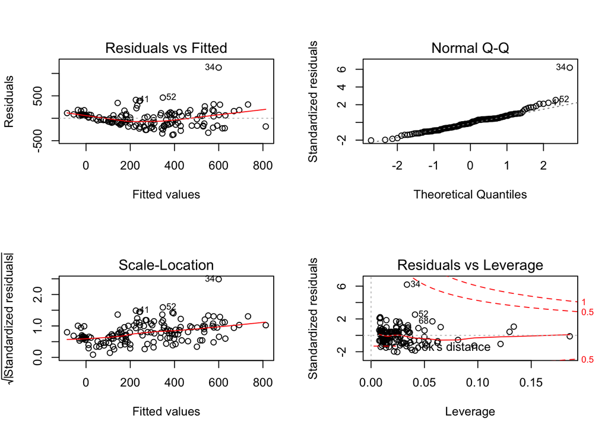

```r
par(mfrow=c(2,2))
plot(model1)
```

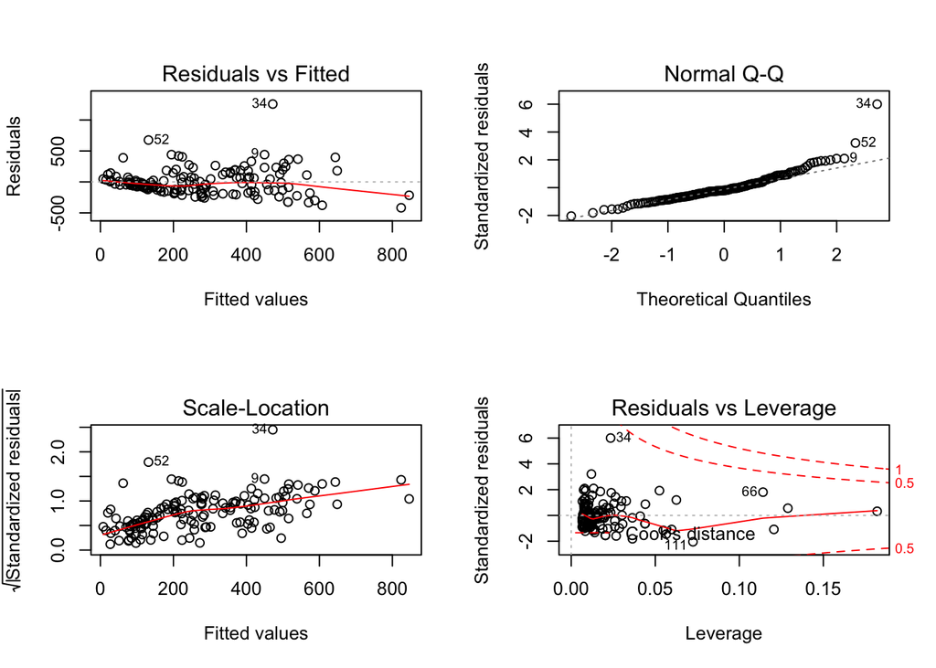

```r
plot(model2)
```